# Expected wins

2017-10-04

Major League Baseball is a sport that loves numbers and statistics.

There is an amazingly simple association between the number of runs a team scores and the number of runs it allows. Bill James and other called this association the **Pythagorean expectation**.

\[W\% = \frac{R^{k}}{R^{k} + RA^{k}}\]

- *R* is the number of runs a team scores.
- *RA* is the number of runs a team allows.
- *k* is an exponant; 2 in our case.
- *W%* is the winning percentage.

Multiply *W* by 162 and you get the number of expected wins.

What is the correlation between the expected number of wins and the actual number of wins? The correlation is **0.97%**!!!

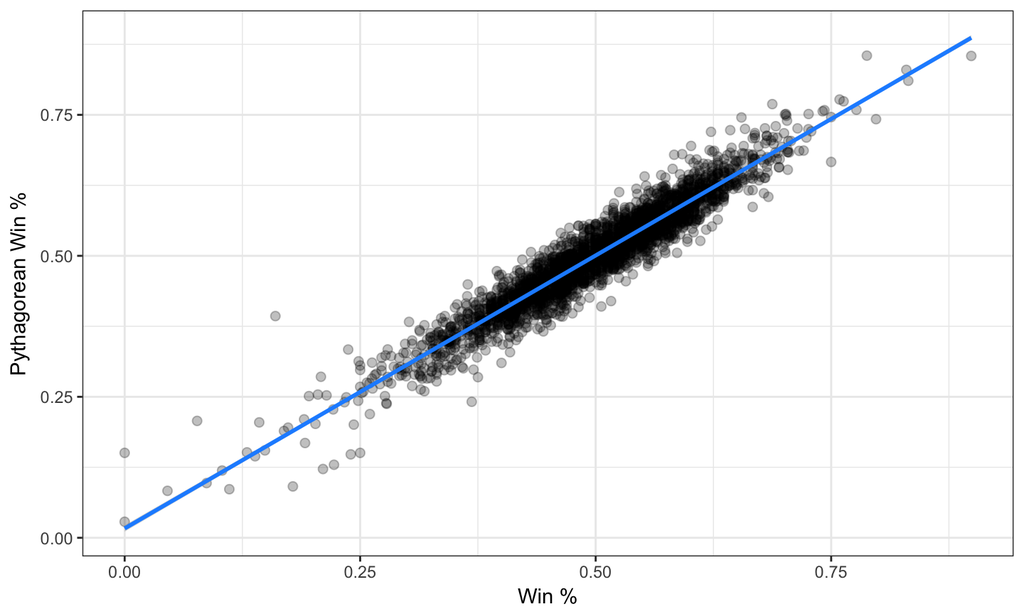

Let's run some code and see how it does:

The 2017 Los Angeles Dodgers scored 770 runs against 580 allowed.

```r
round((770^2 / (770^2 + 580^2)) * 162)
```

```
## [1] 103
```

The *Pythagorean expectation* suggests that the Dodgers should win 103 runs in the 2017 season.

They won 104.

I made a `shiny` app that is hosted on [`shinyapps.io`](https://butterflyology.shinyapps.io/pythagorean_expectation/). This app allows the user to provide a reasonable number of runs scored and allowed and then returns the number of expected wins.

[figure not shown]

The code for all of this lives on my [`GitHub`](https://github.com/butterflyology/DDP_HW4/)